# Do Brooks’ (2020) Identifying Assumptions Hold in Uganda?

Empirical Stress-Test at River Crossing Points — Mt. Elgon, Uganda

Author

Lucas Sempé · 3ie

Published

February 27, 2026

**Summary of findings:** In bivariate balance tests, the composite difficulty index (PC1 — now incorporating stream order from the 19 m DEM) shows 0/7 statistically significant associations with baseline economic characteristics — consistent with the null of orthogonality given 7 simultaneous tests at α = 0.05. After conditioning on elevation and distance to Kampala, 0/7 associations remain — **full orthogonality after geographic controls**. Two additional wealth proxies (Meta RWI and child dependency ratio) extend coverage to household-level corroboration. Note: spatial autocorrelation in balance-test residuals persists after geographic controls, indicating some residual geographic clustering beyond elevation and distance to Kampala. Brooks (2020) already controls for distance-to-town and flood intensity in their balance tests, so **their design is empirically defensible**.

# 1 Study Area

The study covers river crossing points in the **Mt. Elgon region of eastern Uganda** (Mbale and Sironko districts). The Mt. Elgon massif rises to 4,321 m on the Uganda–Kenya border, draining a dense network of rivers that descend through agricultural land to the plains below. Communities on either side of these rivers depend on seasonal fords or informal crossings. This is one of the programme areas where Fika (formerly Bridges to Prosperity) has assessed and built pedestrian suspension bridges.

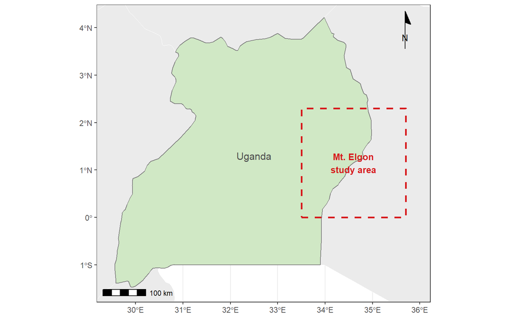

Figure 1: **Regional overview.** The study area (dashed box) sits in eastern Uganda on the Mt. Elgon massif. Neighbouring countries shown for reference.

[interactive chart not shown]

Figure 2: **Interactive map of the 124 river crossing points.** Markers are coloured by waterway type (blue = river, light blue = stream, grey = drain/canal). Click a marker for details. Zoom in to see individual crossing locations.

# 2 Data

## 2.1 River crossing points

Each crossing point is the geometric intersection of an OSM road and an OSM river. This captures all road-accessible river crossings in the study area, including paved bridges, culverts, and seasonal fords. Attributes retained from OSM: road type, pedestrian-priority flag, river name, OSM IDs.

## 2.2 Engineering difficulty proxies

Four proxies capture the engineering constraints that determine whether Bridges to Prosperity constructs a bridge:

Table 1: **Engineering difficulty proxies.** Flood Q50 is derived from catchment area and mean annual precipitation via the FEHSSA regression approach. All four continuous proxies are included in the composite PC1 difficulty index.

[output not shown]

## 2.3 Baseline socioeconomic characteristics

These are **not outcomes of the bridge program**. They are satellite- and OSM-derived proxies for the economic environment that existed at each crossing *before any bridge was built*. The empirical test asks whether a site’s engineering difficulty predicts these pre-existing conditions. If it does not, then difficult-to-bridge and easy-to-bridge crossings sit in comparable economic environments — and treatment assignment via the engineering criterion is as-good-as-random. If it does, then the comparison group is structurally advantaged or disadvantaged before the intervention.

The bridge program’s true causal outcomes (household wage income, consumption, flood-shock resilience) are measured in the Brooks household survey and are not available to us. Our baseline characteristics serve as the closest observable analogue.

Table 2: **Baseline socioeconomic characteristics used in balance tests.** These proxy the economic environment at each crossing site before any bridge is built. They are not the household-level outcomes of the bridge programme (income, consumption, etc.). RWI and dependency ratio (bottom two rows) require P1E to be run first.

| Baseline characteristic | Description | Source | Year | N (of 124) |
| --- | --- | --- | --- | --- |
| Nighttime lights | Mean VIIRS radiance within 2 km — proxy for local economic activity | VIIRS/NPP | 2014 | 122 |
| Population density | WorldPop persons/km² within 2 km | WorldPop | 2015 | 122 |
| Road density | OSM road length (km) per km² within 2 km — infrastructure proxy | OSM | 2024 | 124 |
| Travel time to city | Minutes to nearest city ≥ 50,000 — market access proxy | Weiss et al. | 2019 | 112 |
| Agricultural suitability | Temp × precip suitability index (0–100) — livelihood proxy | WorldClim 2.1 | 1970–2000 | 122 |
| Relative Wealth Index | Meta/HDX asset-based wealth score (~2.4 km tiles) — household wealth proxy | Meta AI Research | 2015–2020 | ~124 |
| Child dependency ratio | Under-15 population / total population within 2 km — demographic structure proxy | WorldPop age-sex structure | 2020 | ~124 |

## 2.4 Geographic controls

Two variables capture the geographic gradient that could simultaneously drive both engineering difficulty and economic outcomes:

- **Elevation** (SRTM 90 m, standardised): separates valley-floor crossings from upland crossings.
- **Distance to Kampala** (km, standardised): a proxy for market integration and state capacity.

These parallel the controls used in Brooks’ baseline balance tests (distance to town; flood intensity).

# 3 Empirical Strategy

## 3.1 The Brooks (2020) design

Brooks (2020, *Econometrica*) exploits two-stage programme selection by Bridges to Prosperity. All candidate villages pass a **needs assessment** (population size, market proximity, expected use). Among these, some pass and some fail an **engineering feasibility check** based on riverbank geometry:

| Criterion | Threshold |
| --- | --- |
| Maximum span | ≤ 100 m |
| Crest height differential | ≤ 3 m |
| High-water mark clearance | ≥ 2 m below deck |
| Soil stability & erosion | Pass/fail |

Villages that **pass both** stages receive a bridge. Villages that **pass needs but fail engineering** serve as the comparison group. Because failure is caused by river geometry — not by village economic conditions — treatment assignment is argued to be as-good-as-random conditional on comparable need.

Brooks estimates two main specifications. For annual outcomes:

$$y_{ivt} = \alpha + \beta B_{vt} + \eta_t + \delta_v + \varepsilon_{ivt}$$

For high-frequency outcomes with flood interactions:

$$y_{ivt} = \eta_t + \delta_i + \beta B_{vt} + \gamma F_{vt} + \theta (B_{vt} \times F_{vt}) + \varepsilon_{ivt}$$

where $B_{vt} = 1$ if village $v$ has a bridge at time $t$, $F_{vt}$ is a flood shock, and village fixed effects $\delta_v$ absorb time-invariant selection.

## 3.2 Our three empirical tests

**Test A — Bivariate balance test:** For each combination of difficulty proxy $D$ and baseline characteristic $Y$, we estimate:

$$Y_i = \alpha + \beta \cdot D_i + \varepsilon_i$$

This is a balance test. $\hat\beta \approx 0$ means the engineering difficulty of a crossing does not predict the pre-existing economic conditions at that site — the core of Brooks’ orthogonality claim.

**Test B — Geography-conditional balance test:** We add elevation and distance to Kampala to isolate any residual confounding after the main geographic gradient is removed:

$$Y_i = \alpha + \beta \cdot D_i + \gamma_1 \cdot \text{elev}_i + \gamma_2 \cdot \text{dist\_kampala}_i + \varepsilon_i$$

If $\hat\beta$ becomes significant here but was not in Test A, engineering difficulty is correlated with baseline conditions *through* geography: large rivers run through valleys where economic activity concentrates. This means geographic controls must be included in any analysis using this design.

**Test C — Spatial autocorrelation (Moran’s I):** We test whether the balance-test residuals cluster geographically using $k = 5$ nearest-neighbour spatial weights. A significant Moran’s I means that nearby crossings share similar economic environments beyond what the difficulty proxy alone explains — signalling that omitted geographic confounders are at work.

## 3.3 Composite difficulty index (PCA)

Individual proxies each capture one facet of engineering difficulty. We combine them into a single index using principal components analysis (PCA) on all four continuous variables:

$$\text{PC1} = f(\text{slope},\ \log(\text{catchment area}),\ \text{stream order},\ \log(\text{flood Q50}))$$

PC1 is interpreted as a *large-watershed / high-flood* difficulty axis. Sites with large upstream catchments, high Strahler order, and high flood magnitudes (but typically flat terrain) score high; steep upland sites with small catchments score low. The index is estimated on $n$ = 119 crossings with complete data on all four inputs. OSM `waterway_type` is tested separately as a categorical stream-class check.

# 4 Results

## 4.1 Descriptive statistics

Table 3: **Descriptive statistics.** Top panel: engineering difficulty proxies. Middle panel: baseline socioeconomic characteristics (pre-treatment proxies, not programme outcomes). Bottom panel: geographic controls. Separator rows for readability.

| Variable | N | Mean | SD | Median | Min–Max |
| --- | --- | --- | --- | --- | --- |
| Slope (°) | 122 | 4.9 | 4.7 | 3.4 | 0 – 27 |
| Catchment area (km²) | 124 | 157.6 | 789.2 | 2.3 | 0 – 5664 |
| Flood Q50 (m³/s) | 124 | 510.5 | 2069.3 | 40.9 | 1 – 14298 |
| Stream order (Strahler) | 119 | 2.7 | 1.6 | 2.0 | 1 – 8 |
| — — — |  |  |  |  |  |
| Nighttime lights | 122 | 0.0 | 0.1 | 0.0 | 0 – 1 |
| Population density (p/km²) | 122 | 312.3 | 305.0 | 221.5 | 15 – 1555 |
| Road density (km/km²) | 124 | 1.5 | 1.1 | 1.0 | 0 – 4 |
| Travel time (min) | 112 | 60.6 | 51.8 | 58.0 | 0 – 242 |
| Agri. suitability (0–100) | 122 | 90.7 | 7.5 | 93.2 | 63 – 100 |
| Relative Wealth Index | 124 | -0.4 | 0.3 | -0.5 | -1 – 0 |
| Child dep. ratio | 122 | 0.1 | 0.2 | 0.0 | 0 – 1 |
| — —— |  |  |  |  |  |
| Elevation (m) | 121 | 1649.4 | 449.8 | 1797.3 | 886 – 2464 |
| Distance to Kampala (km) | 124 | 273.9 | 55.7 | 285.2 | 135 – 367 |

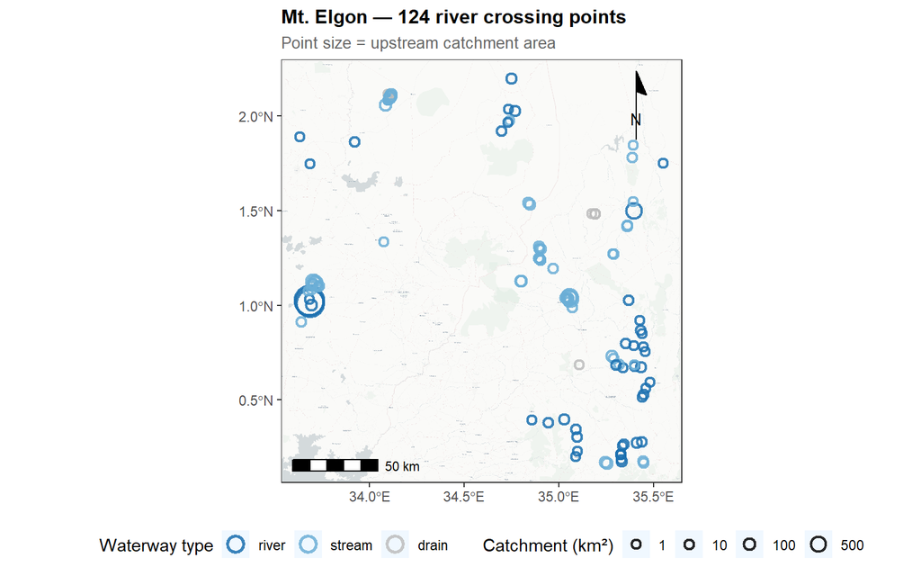

Figure 3: **Crossing points coloured by OSM waterway type** (Carto Light basemap). River crossings (blue) concentrate in the lower valleys; stream crossings (light blue) are scattered across upland areas. Point size proportional to upstream catchment area.

## 4.2 The difficulty composite index

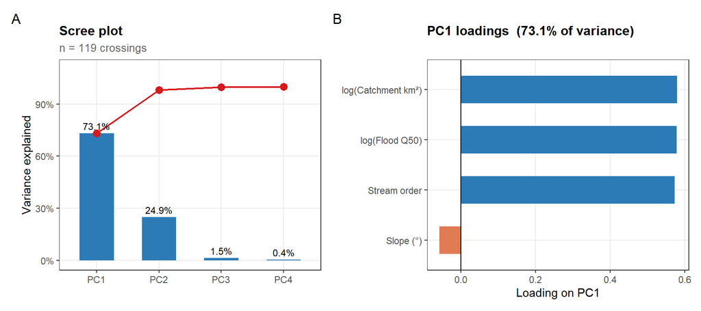

PC1 explains **73.1%** of the shared variance. It is best understood as a *watershed size* axis: sites on large, low-gradient rivers score high; steep upland crossings score low. The negative slope loading reflects the landscape structure — flat valley rivers have large catchments; steep upland streams have small ones.

## 4.3 Test A — Bivariate balance tests

For each of the 5 difficulty proxies and each of the 7 baseline characteristics, we ask: does difficulty predict this pre-existing condition? The figure below shows the OLS coefficient as a colour-coded tile; a star marks associations that survive FDR correction (Benjamini-Hochberg q < 0.05) applied across all 35 bivariate tests. The key proxy is the **composite PC1 index** (rightmost column); the individual component proxies are shown for transparency.

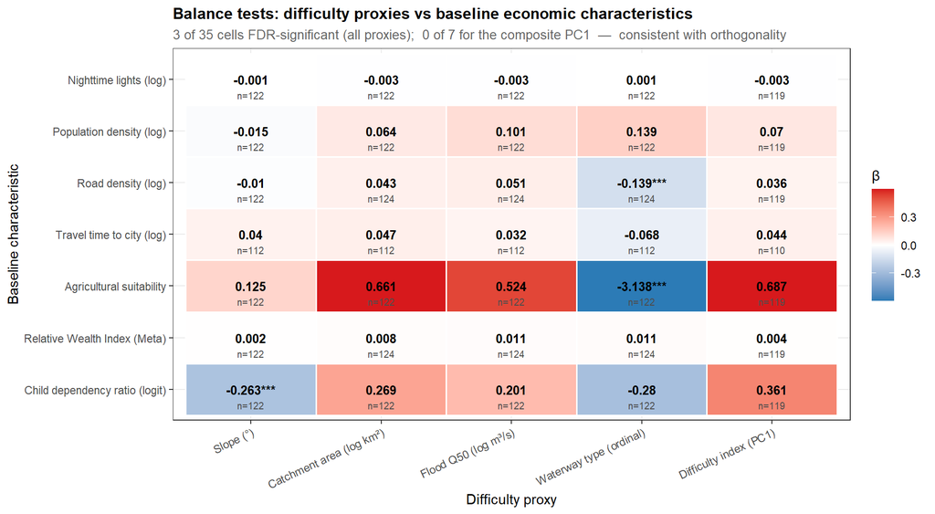

Figure 5: **Bivariate balance test heatmap.** Each cell shows the OLS coefficient from regressing the row *baseline characteristic* on the column *difficulty proxy* — a balance test, not a causal regression. Stars indicate FDR-adjusted significance (Benjamini-Hochberg, q < 0.05): 3 of 35 cells; the composite PC1 index shows 0 of 7 significant. N for each regression shown in parentheses.

## 4.4 Test B — Balance tests conditional on geography

We add elevation and distance to Kampala as controls and repeat every balance test. This answers: even within the same geographic zone, does difficulty still predict baseline conditions? The coefficient plot overlays the bivariate (orange) and conditional (blue) estimates for the composite difficulty index.

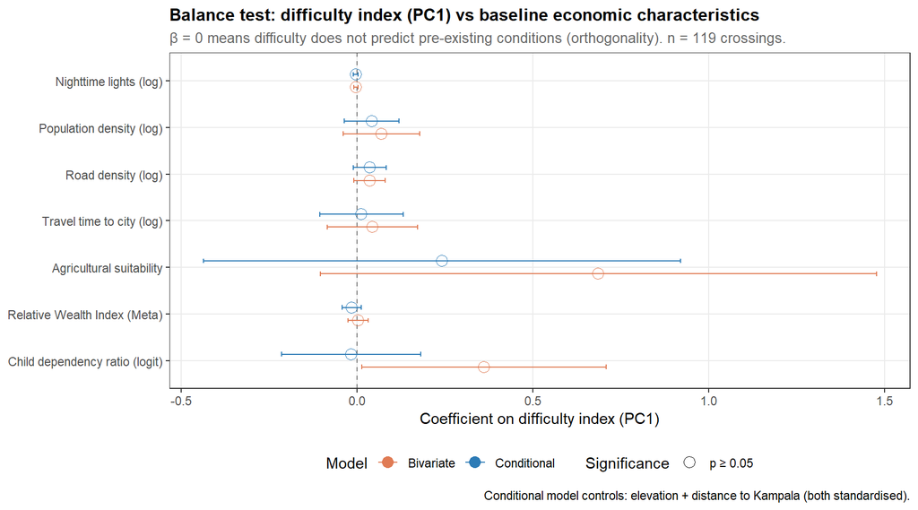

Figure 6: **Balance test: bivariate vs geography-conditional.** Each row is a baseline characteristic; filled symbols = p < 0.05. Orange = bivariate (no controls); blue = conditional (+ elevation + distance to Kampala). Whiskers show 95% confidence intervals.

Table 4: **Geography-conditional balance tests: difficulty index (PC1) vs baseline characteristics.** Controls: elevation (std.) and distance to Kampala (std.). Stars show FDR-adjusted significance (BH q < 0.05); raw p-values shown for reference. A significant β means that, within the same geographic band, difficulty still predicts pre-existing conditions.

| Outcome | β | SE | 95% CI | p (raw) | q (BH) | N |
| --- | --- | --- | --- | --- | --- | --- |
| Nighttime lights (log) | -0.0029 | 0.0034 | [-0.0097, 0.0039] | 0.399 | 0.578 | 118 |
| Population density (log) | 0.0423 | 0.0393 | [-0.0355, 0.1201] | 0.284 | 0.530 | 118 |
| Road density (log) | 0.0359 | 0.0236 | [-0.0108, 0.0826] | 0.130 | 0.415 | 118 |
| Travel time to city (log) | 0.0124 | 0.0598 | [-0.1062, 0.1311] | 0.836 | 0.860 | 110 |
| Agricultural suitability | 0.2416 | 0.3425 | [-0.4369, 0.92] | 0.482 | 0.582 | 118 |
| Relative Wealth Index (Meta) | -0.0151 | 0.0136 | [-0.042, 0.0118] | 0.270 | 0.530 | 118 |
| Child dependency ratio (logit) | -0.0170 | 0.0999 | [-0.2149, 0.1808] | 0.865 | 0.865 | 118 |

**Test B result: 0 of 7 baseline characteristics are significantly associated with difficulty** after geographic controls.

**Child dependency ratio** is not significantly associated with difficulty after geographic controls.

## 4.5 Test C — Spatial autocorrelation

If crossing-level baseline characteristics cluster spatially beyond what the difficulty index explains, there are omitted geographic confounders — meaning the balance test understates the true correlation between difficulty and pre-existing conditions. We compute Moran’s I on the residuals of the NTL balance regression under both the bivariate and conditional specifications.

Table 5: **Moran’s I on regression residuals.** Moran’s I > 0 with p < 0.05 means the baseline characteristic (NTL) clusters spatially beyond what the model explains — indicating omitted geographic confounders. k = 5 nearest-neighbour spatial weights.

| Model | Moran's I | p-value | Interpretation |
| --- | --- | --- | --- |
| Bivariate (difficulty only) | 0.219 | 0.0000 | Significant clustering — geographic confounders present |
| Conditional (+ elevation + dist. Kampala) | 0.211 | 0.0000 | Significant clustering remains after geographic controls |

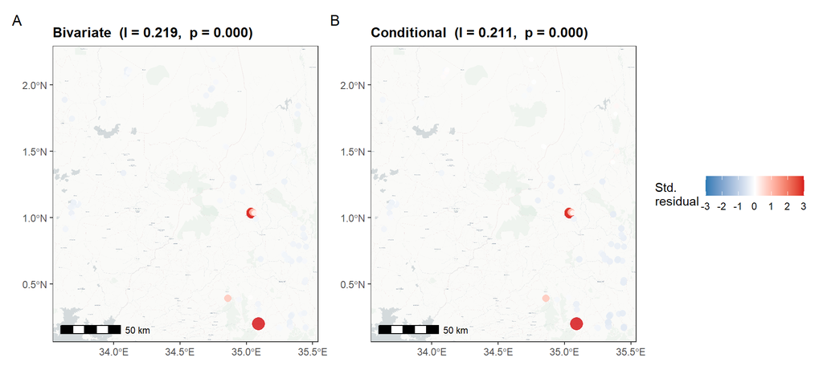

Figure 7: **Spatial distribution of NTL balance-test residuals.** Each point is one crossing, coloured by its standardised regression residual (red = higher NTL than model predicts; blue = lower). Left: bivariate model (Moran’s I = 0.219, p = 0.000) — red and blue points cluster geographically, confirming spatial autocorrelation. Right: conditional model (I = 0.211, p = 0.000) — clustering is reduced but statistically significant.

The bivariate residuals show significant spatial clustering (I = 0.219, p = 0.000)`: the nighttime-lights environment at nearby crossings is more similar than expected by chance. Once elevation and distance to Kampala are included, clustering drops to I = 0.211 (p = 0.000) — still above the conventional threshold. **Residual spatial clustering remains after controls**, suggesting additional geographic confounders may be present.